# EXPLORATORY DATA ANALYSIS OF WHITE WINE

White wine has existed for at least 2500 years. I’m going to gain some knowledge of wine by conducting the exploratory data analysis of the data set with the physicochemical and quality of the wine.

The scope of this analysis is to understand relationship of various parameters which impact the quality ratings for White wine.The data set consists of 4000+ sample data for combined White wine.

The analysis will have additional focus on the following key parameters such as Alcohol, pH, residual sugar.

# Univariate Plots Section

```
## [1] 4898   13
```

This data set contains 4,898 white wines with 11 variables on quantifying the chemical properties of each wine. At least 3 wine experts rated the quality of each wine, providing a rating between 0 (very bad) and 10 (very excellent).

```
##  [1] "X"                    "fixed.acidity"        "volatile.acidity"
##  [4] "citric.acid"          "residual.sugar"       "chlorides"
##  [7] "free.sulfur.dioxide"  "total.sulfur.dioxide" "density"
## [10] "pH"                   "sulphates"            "alcohol"
## [13] "quality"
```

Here, is a list of variable names in the dataset.

```
## 'data.frame':    4898 obs. of  13 variables:
##  $ X                   : int  1 2 3 4 5 6 7 8 9 10 ...
##  $ fixed.acidity       : num  7 6.3 8.1 7.2 7.2 8.1 6.2 7 6.3 8.1 ...
##  $ volatile.acidity    : num  0.27 0.3 0.28 0.23 0.23 0.28 0.32 0.27 0.3 0.22 ...
##  $ citric.acid         : num  0.36 0.34 0.4 0.32 0.32 0.4 0.16 0.36 0.34 0.43 ...
##  $ residual.sugar      : num  20.7 1.6 6.9 8.5 8.5 6.9 7 20.7 1.6 1.5 ...
##  $ chlorides           : num  0.045 0.049 0.05 0.058 0.058 0.05 0.045 0.045 0.049 0.044 ...
##  $ free.sulfur.dioxide : num  45 14 30 47 47 30 30 45 14 28 ...
##  $ total.sulfur.dioxide: num  170 132 97 186 186 97 136 170 132 129 ...
##  $ density             : num  1.001 0.994 0.995 0.996 0.996 ...
##  $ pH                  : num  3 3.3 3.26 3.19 3.19 3.26 3.18 3 3.3 3.22 ...
##  $ sulphates           : num  0.45 0.49 0.44 0.4 0.4 0.44 0.47 0.45 0.49 0.45 ...
##  $ alcohol             : num  8.8 9.5 10.1 9.9 9.9 10.1 9.6 8.8 9.5 11 ...
##  $ quality             : int  6 6 6 6 6 6 6 6 6 6 ...
```

All the independent variables are numerics and the quality - expert review - is integer. If might be helpful for the further exploration to operate quality as a factor variable, so I createthe new variable and call it quality_rate. It has three levels, “low” with quality rating <= 5, “average” with quality rating == 6 and “high” with quality rating > 6.

```
##        X        fixed.acidity    volatile.acidity  citric.acid
##  Min.   :   1   Min.   : 3.800   Min.   :0.0800   Min.   :0.0000
##  1st Qu.:1225   1st Qu.: 6.300   1st Qu.:0.2100   1st Qu.:0.2700
##  Median :2450   Median : 6.800   Median :0.2600   Median :0.3200
##  Mean   :2450   Mean   : 6.855   Mean   :0.2782   Mean   :0.3342
##  3rd Qu.:3674   3rd Qu.: 7.300   3rd Qu.:0.3200   3rd Qu.:0.3900
##  Max.   :4898   Max.   :14.200   Max.   :1.1000   Max.   :1.6600
##  residual.sugar     chlorides       free.sulfur.dioxide
##  Min.   : 0.600   Min.   :0.00900   Min.   :  2.00
##  1st Qu.: 1.700   1st Qu.:0.03600   1st Qu.: 23.00
##  Median : 5.200   Median :0.04300   Median : 34.00
##  Mean   : 6.391   Mean   :0.04577   Mean   : 35.31
##  3rd Qu.: 9.900   3rd Qu.:0.05000   3rd Qu.: 46.00
##  Max.   :65.800   Max.   :0.34600   Max.   :289.00
##  total.sulfur.dioxide    density             pH          sulphates
##  Min.   :  9.0        Min.   :0.9871   Min.   :2.720   Min.   :0.2200
##  1st Qu.:108.0        1st Qu.:0.9917   1st Qu.:3.090   1st Qu.:0.4100
##  Median :134.0        Median :0.9937   Median :3.180   Median :0.4700
##  Mean   :138.4        Mean   :0.9940   Mean   :3.188   Mean   :0.4898
##  3rd Qu.:167.0        3rd Qu.:0.9961   3rd Qu.:3.280   3rd Qu.:0.5500
##  Max.   :440.0        Max.   :1.0390   Max.   :3.820   Max.   :1.0800
##     alcohol         quality      quality_rate
##  Min.   : 8.00   Min.   :3.000   Length:4898
##  1st Qu.: 9.50   1st Qu.:5.000   Class :character
##  Median :10.40   Median :6.000   Mode  :character
##  Mean   :10.51   Mean   :5.878
##  3rd Qu.:11.40   3rd Qu.:6.000
##  Max.   :14.20   Max.   :9.000
```

Observations from the Summary

1. There is a big range for sulfur.dioxide (both Free and Total) across the samples.
2. Structure of the dataset - There are 4898 observations of wine with 12 variables (11 numeric physicochemical properties and one integer expert review).
3. The alcohol content varies from 8.00 to 14.20 for the samples in dataset.
4. The quality of the samples range from 3 to 9 with 6 being the median.
5. The range for fixed acidity is quite high with minimum being 3.8 and maximum being 14.20.
6. pH value varies from 2.720 to 3.820 with a median being 3.180.

# Understanding the overall distribution

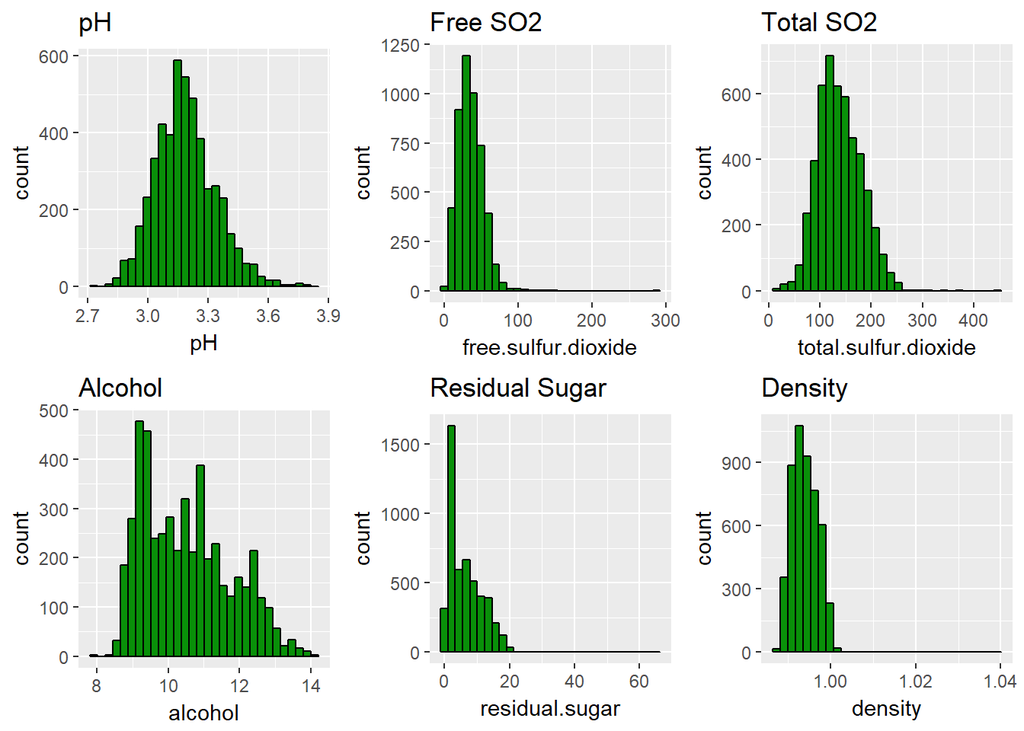

As assumed most of the variables (except Residual Sugar and Alcohol) represent simmetrical distribution with the right tails.

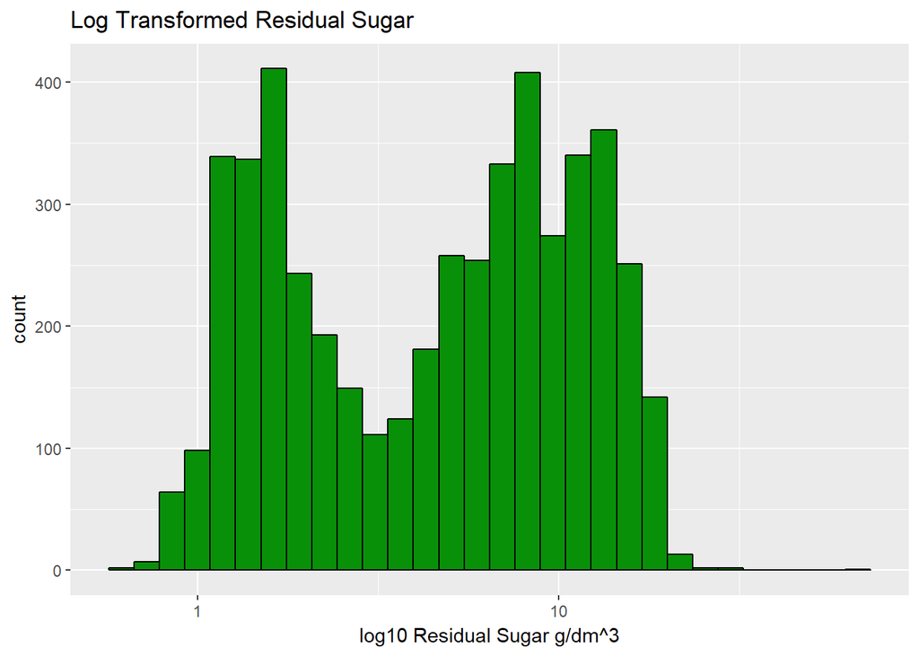

Some observations from the univariate plots are as below:

### The spread of the quality analysis are given as below:

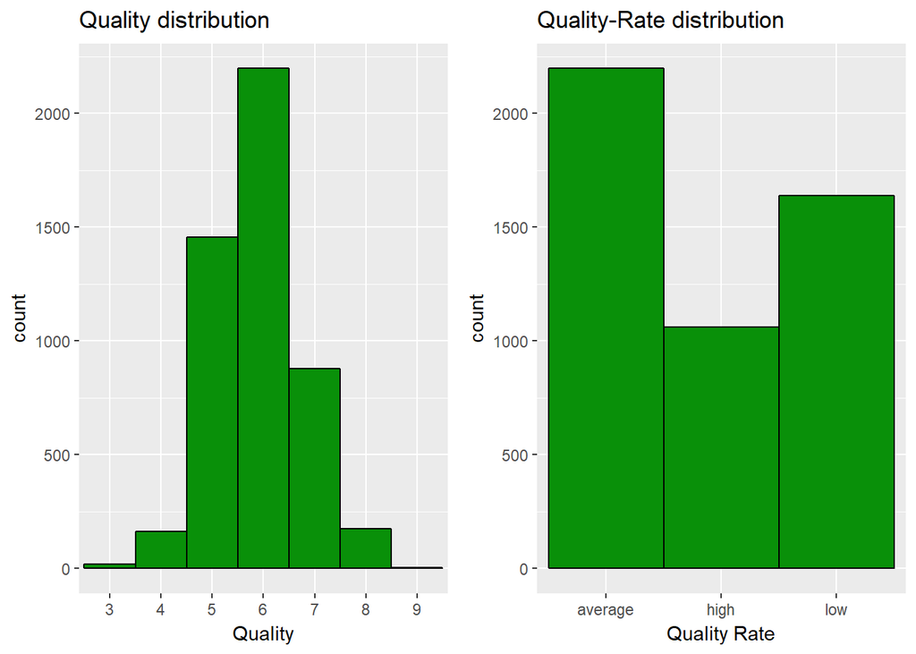

The spread for the quality rate has a high count for average rating that is a quality of 6, followed by ‘low’ rating that is a quality of less than or equal to 5 and the last for ‘high’ rating that is a quality greater than 6. # Univariate Analysis

### What is the structure of your dataset?

There are 4898 observations of wine with 12 variables (11 numeric physicochemical properties and one integer expert review).

### What is/are the main feature(s) of interest in your dataset?

The main features in the data set are quality, alcohol, residual.sugar, density.

### What other features in the dataset do you think will help support your investigation into your feature(s) of interest?

Sulfur dioxide, citric acid, clorides.

### Did you create any new variables from existing variables in the dataset?

Yes, I’m have created new quality variable quality_rate to union rare wine with rare quality scores (3, 4, 5 union in “low”; 6 to “average”, 7, 8, 9 union in “high”)

New variable have 3 groups of wine quality with relatively big amount of observations in each group.

### Of the features you investigated, were there any unusual distributions? Did you perform any operations on the data to tidy, adjust, or change the form of the data? If so, why did you do this?

I log-transformed the right skewed Residual Sugar distribution. The tranformed distribution appears bimodal with the peaking around 1 or so and again around 8 g/dm^3.

# Bivariate Plots Section

A scatterplot matrix is derived to understand the overall variable behaviour and correlations

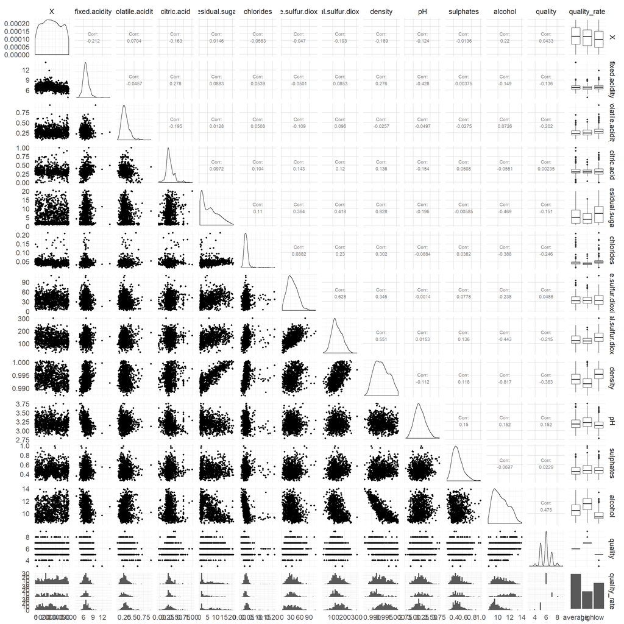

Scatterplot output indicates the following correlation behaviour :

Free SO2 Noticeable positive correlation with Total SO2 and Residual sugar, Negative correlation with pH and Alcohol

Total So2 Positive correlation between free so2 and residual sugar, Negative correlation with Alcohol

pH Positive correlation with Sulphate, Total SO2 and Alcohol, Negative correlation with Free SO2, Residual sugar,citric acid, volatile acidity

Alcohol Positive correlation with pH and quality, Negative Correlation with density,total and free so2,chlorides

Quality Positive correlation with alcohol, Negative correaltion with density,chlorides,volatile acidity

Let’s visualize density on frequency polygon and color it by quality:

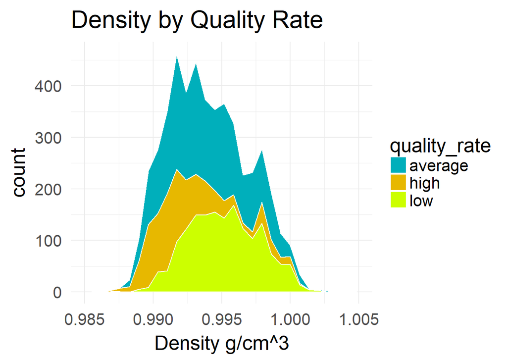

Most quality wine has lower density and it’s quite clear on this kind of the visualization. All other features seems not to be important for the quality.

# Bivariate Analysis

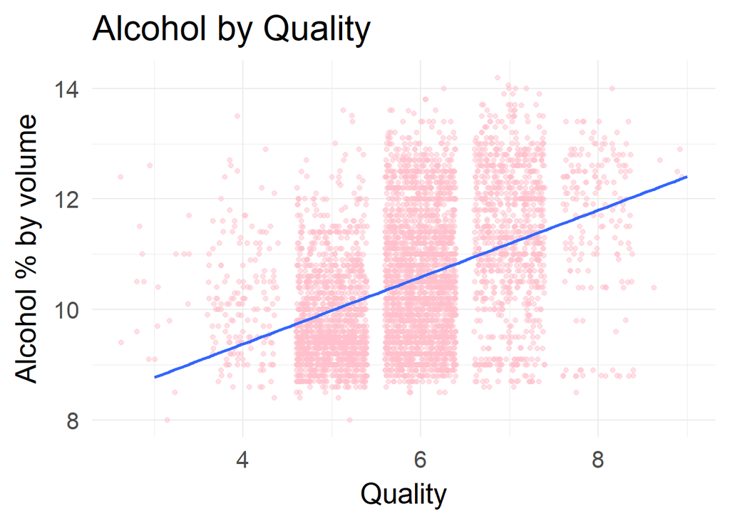

The median of alcohol variable by quality is higher for higher quality white wine. This follows that one of the main features of high quality wine has high alcohol content.

### Talk about some of the relationships you observed in this part of the investigation. How did the feature(s) of interest vary with other features in the dataset?

Let’s dive a little more to explore relationship between alcohol and sugar:

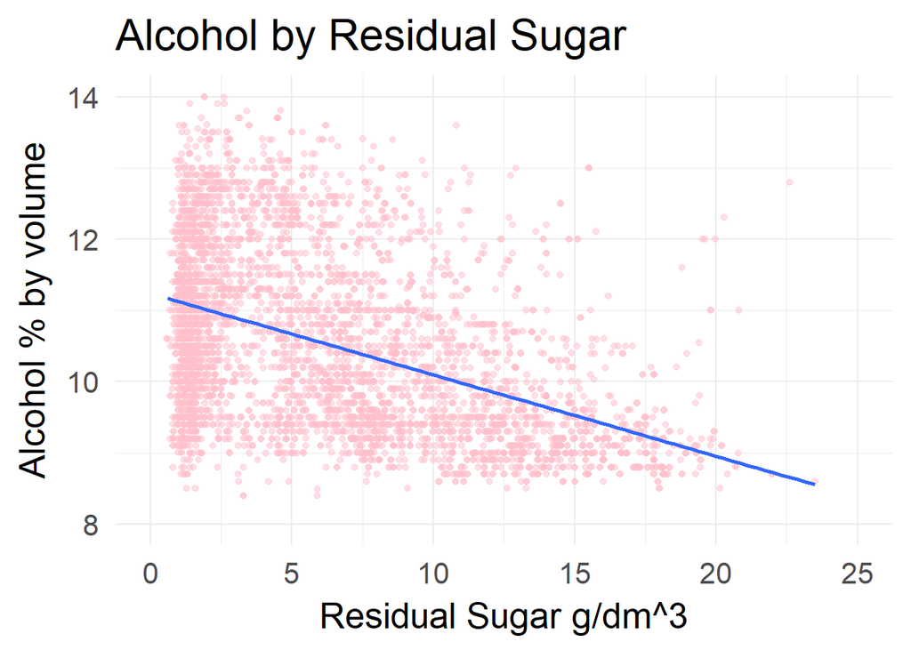

There is some correlation between alochol and sugar. And that’s fair enough: sweet wines, are where the fermentation is interrupted before all the grape sugars are converted into alcohol: this is called Mutage or fortification. That means sweeter the wine (more sugar in the wine) - less alcohol.

Now let’s look at the correlation between total sulfur dioxide and sugar :

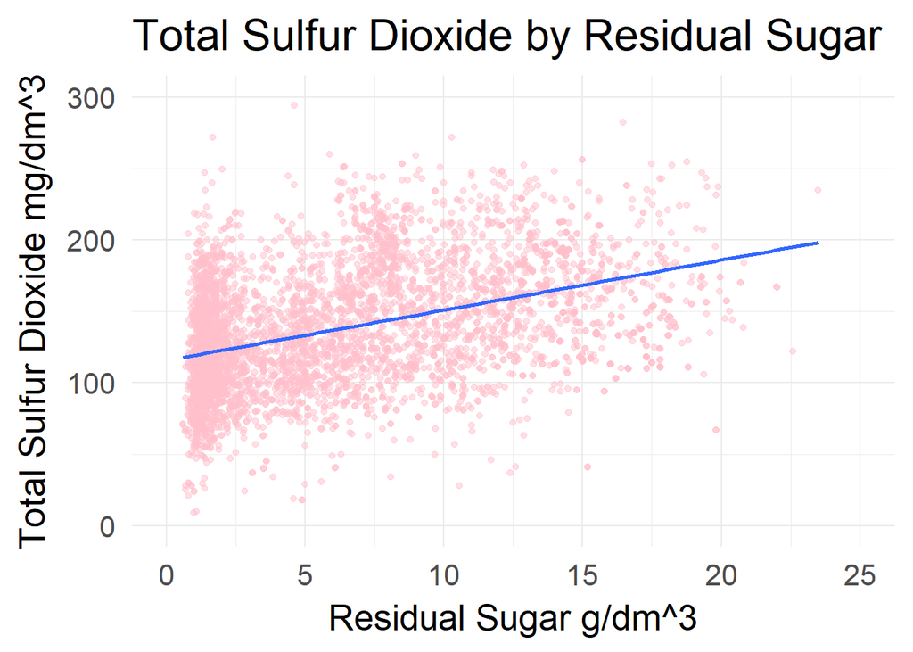

There is also quite a strong correlation between SO2 and sugar. That’s because SO2, sulphur dioxide, plays a protective role in the wine against the phenomena of oxidation, oxidase enzyme action (enzymes that oxidize the polyphenols in wine), and the control of microbial populations in yeasts and bacteria (antiseptic effect). The maximum allowable doses depend on the sugar content of the wine: the residual sugar is susceptible to attack by microorganisms which would cause a restart of fermentation.

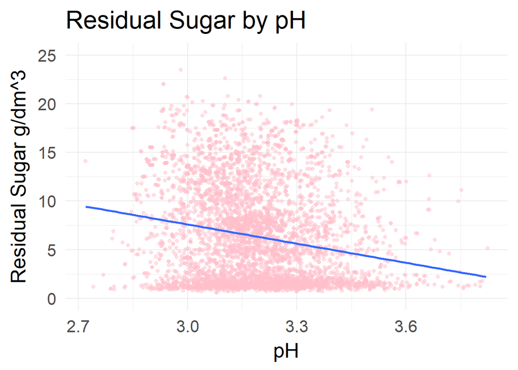

### What was the strongest relationship you found?

Sugar and density

# Multivariate Plots Section

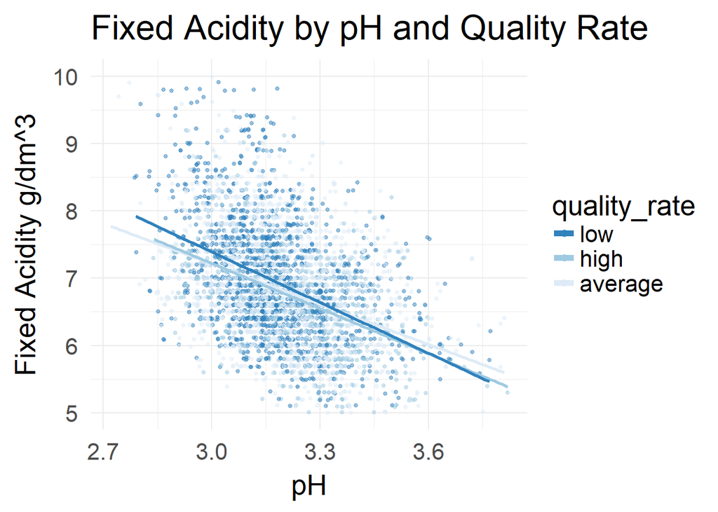

Now I’m going to explore density as it has relationships with lot’s of other variables. There is a strong positive correlation between density and sugar. Let’s visualize density and try find some logic.

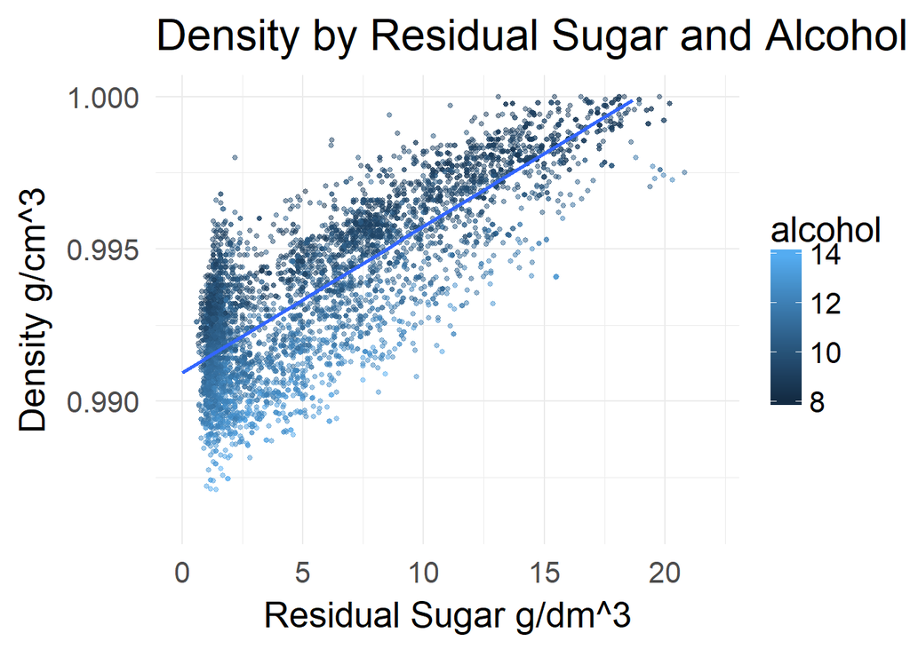

This visualization gives us 2 ideas: sweater wine has more density and wine with the same sweetness has larger volume of alcohol with lower density.

The most powerful features lies around quality of wine, alcohol and density. Density has also a strong relationship with sugar.

# Final Plots and Summary

### Plot One

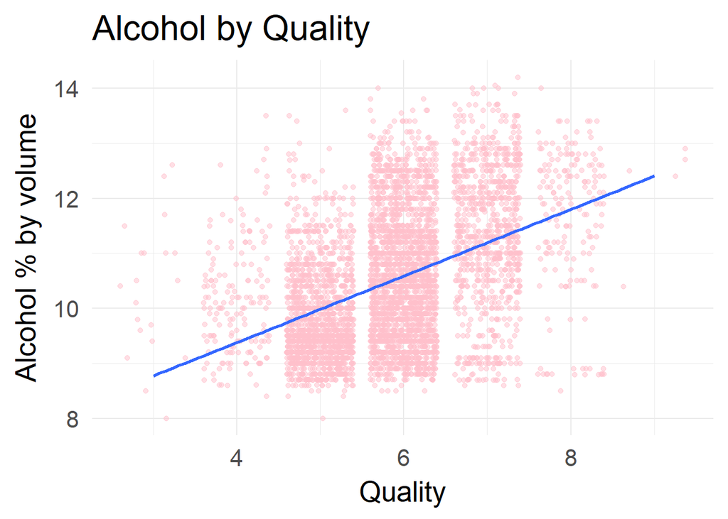

### Description One

This visualization gives shows strong positive correlation between alcohol and quality. The median of alcohol variable by quality is higher for higher quality white wine. This follows that one of the main features of high quality wine has high alcohol content.

### Plot Two

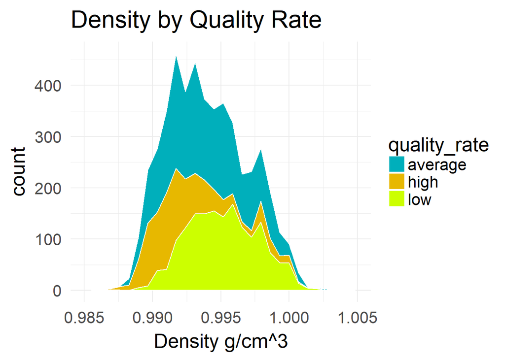

### Description Two

Density is an important feature of the wine. Based on our exloratory data analysis, it’s second most important for the quality and has negative correlation. The reader can see it clearly on the current visualisation of frequency polygon. The outcome is the following: the better wine tend to have lower density.

### Plot Three

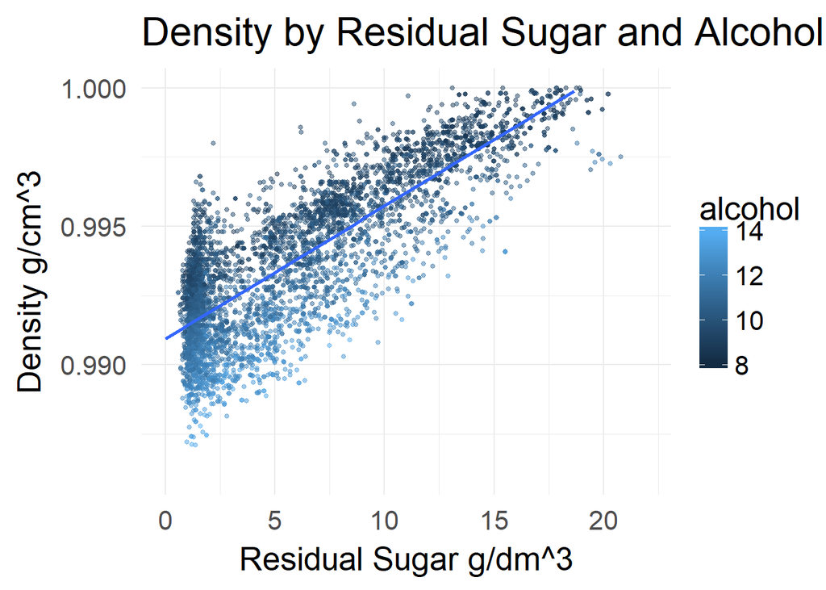

### Description Three

We’ve also found some interesting knowledge in the wine physicochemical properties, exploring correlation of residual sugar, density: sweater wine has more density and wine with the same sweetness has larger volume of alcohol with lower density. Anotherwords, looking for the good wine with larger volume of alcohol and knowing what sweetness you like more you could expect lower density.

# Reflection

For this exploration, I researched and understood a little about wine making and how each variable contributes to a good quality wine. Some of my observations after performing exploratory analysis is, Good wine tend to have more alcohol. Alcohol probably creates the flavor or sugar (as an alternative to alcohol) kills it Good wine tend to have lower density. Again that might be because of sugar (density increases with the increase of sugar) or SO2. As we know from the description, everyone uses SO2 but too much of it might harm the wine and increase density

Limitations of the study - Our data set represent just several thousands wine from particular region. Measures used to collect the data. The quality review is a person’s opinion of the particular sommelier.